# Correlation of PARP1 with CTCF ChIP-Seq

We will analyze the correlation of nucleosome associated PARP1 reads with CTCF ChIP-seq. The CTCF ChIP-seq is from the UCSC/ENCODE data portal. The PARP1 reads and CTCF ChIP-seq data has already been processed and is made available as part of the fmdatabreastcaparp1 package.

```r
library(GenomicRanges)
library(ggplot2)
library(BSgenome.Hsapiens.UCSC.hg19)
library(fmcorrelationbreastcaparp1)
library(fmdatabreastcaparp1)
```

Load the PARP1 data.

```r
data(tss_windows)
data(parp1_ln4_unique)
data(parp1_ln5_unique)
```

Calculate the weighted coverage of the ln4 and ln5 sample reads, and then sum the reads in each TSS window.

```r
mcf7_cov <- coverage(parp1_ln4_unique, weight = "n_count")
mdamb231_cov <- coverage(parp1_ln5_unique, weight = "n_count")

tss_windows <- binned_function(tss_windows, mcf7_cov, "sum", "parp1_mcf7")
tss_windows <- binned_function(tss_windows, mdamb231_cov, "sum", "parp1_mdamb231")
```

Load the CTCT ChIP-seq data, and average the ChIP-seq peaks in each TSS window.

```r
data(ctcf_rep1)
data(ctcf_rep2)
ctcf_r1_cov <- coverage(ctcf_rep1, weight = "mcols.signal")
ctcf_r2_cov <- coverage(ctcf_rep2, weight = "mcols.signal")
tss_windows <- binned_function(tss_windows, ctcf_r1_cov, "mean_nozero", "ctcf_r1")
tss_windows <- binned_function(tss_windows, ctcf_r2_cov, "mean_nozero", "ctcf_r2")
```

Now with the Parp1 reads and CTCF ChIP-Seq data, we can start doing some correlations.

```r
non_zero <- "both"
```

Start with a sampling of points and graph and generate a correlation.

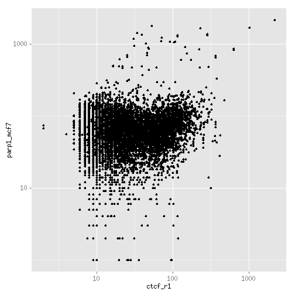

```r
r1_v_mcf7 <- subsample_nonzeros(mcols(tss_windows), c("ctcf_r1", "parp1_mcf7"), non_zero = non_zero, n_points = 10000)
ggplot(r1_v_mcf7, aes(x = ctcf_r1, y = parp1_mcf7)) + geom_point() + scale_y_log10() + scale_x_log10()
```

```r
cor(log10(r1_v_mcf7[,1]+1), log10(r1_v_mcf7[,2]+1))
```

```
## [1] 0.1219387
```

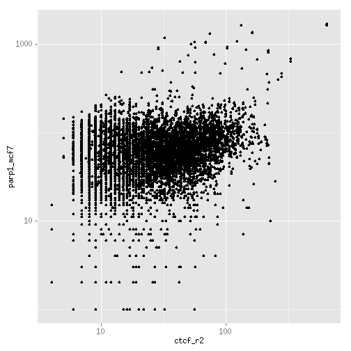

```r
r2_v_mcf7 <- subsample_nonzeros(mcols(tss_windows), c("ctcf_r2", "parp1_mcf7"), non_zero = non_zero, n_points = 10000)
ggplot(r2_v_mcf7, aes(x = ctcf_r2, y = parp1_mcf7)) + geom_point() + scale_y_log10() + scale_x_log10()
```

```r
cor(log10(r2_v_mcf7[,1]+1), log10(r2_v_mcf7[,2]+1))
```

```
## [1] 0.2111723
```

Now do them all.

```r
all_comb <- expand.grid(c("ctcf_r1", "ctcf_r2"), c("parp1_mcf7", "parp1_mdamb231"), stringsAsFactors = FALSE)
out_cor <- lapply(seq(1, nrow(all_comb)), function(i_row){
  #print(i_row)
  correlate_non_zero(mcols(tss_windows), as.character(all_comb[i_row,]), log_transform = TRUE, non_zero = non_zero, test = TRUE)
})
all_comb_names <- paste(all_comb[,1], all_comb[,2], sep = "_v_")
out_cor <- do.call(rbind, out_cor)
rownames(out_cor) <- all_comb_names
```

TSS correlations:

|  | corr_value | p_value |
| --- | --- | --- |
| ctcf_r1_v_parp1_mcf7 | 0.1138285 | 0 |
| ctcf_r2_v_parp1_mcf7 | 0.1959455 | 0 |
| ctcf_r1_v_parp1_mdamb231 | 0.0446777 | 0 |
| ctcf_r2_v_parp1_mdamb231 | 0.0830321 | 0 |

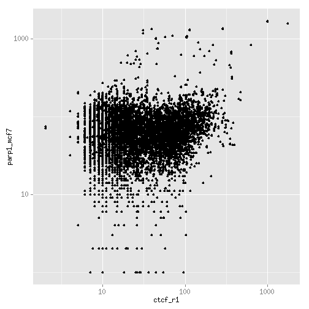

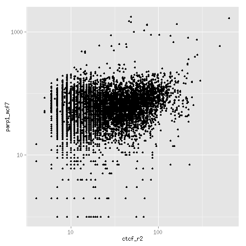

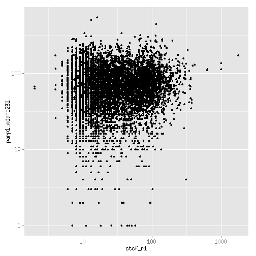

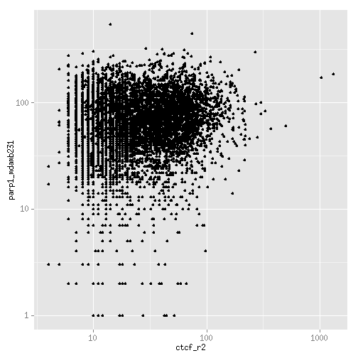

```r
out_graphs <- lapply(seq(1, nrow(all_comb)), function(i_row){
  use_vars <- as.character(all_comb[i_row,])
  subpoints <- subsample_nonzeros(mcols(tss_windows), use_vars, non_zero = non_zero, n_points = 10000)
  ggplot(subpoints, aes_string(x = use_vars[1], y = use_vars[2])) + geom_point() + scale_y_log10() + scale_x_log10()
})
out_graphs
```

### Genome Wide Comparison

Are these correlations a result of association with the TSS's? One way to test this is to set up a calculation genome-wide.

```r
genome_tiles <- tileGenome(seqinfo(Hsapiens), tilewidth = 2000, cut.last.tile.in.chrom = TRUE)

genome_tiles <- binned_function(genome_tiles, mcf7_cov, "sum", "parp1_mcf7")
genome_tiles <- binned_function(genome_tiles, mdamb231_cov, "sum", "parp1_mdamb231")
genome_tiles <- binned_function(genome_tiles, ctcf_r1_cov, "mean_nozero", "ctcf_r1")
genome_tiles <- binned_function(genome_tiles, ctcf_r2_cov, "mean_nozero", "ctcf_r2")
```

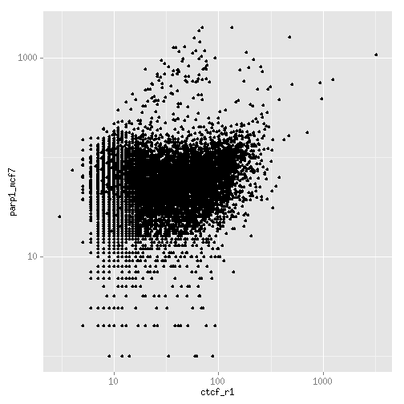

```r
genome_r1_v_mcf7 <- subsample_nonzeros(mcols(genome_tiles), c("ctcf_r1", "parp1_mcf7"), non_zero = non_zero, n_points = 10000)
ggplot(genome_r1_v_mcf7, aes(x = ctcf_r1, y = parp1_mcf7)) + scale_x_log10() + scale_y_log10() + geom_point()
```

```r
cor(log(genome_r1_v_mcf7[,1]+1), log(genome_r1_v_mcf7[,2]+1))
```

```
## [1] 0.181062
```

```r
genome_cor <- lapply(seq(1, nrow(all_comb)), function(i_row){
  #print(i_row)
  correlate_non_zero(mcols(genome_tiles), as.character(all_comb[i_row,]), log_transform = TRUE, non_zero = non_zero, test = TRUE)
})
all_comb_names <- paste(all_comb[,1], all_comb[,2], sep = "_v_")
genome_cor <- do.call(rbind, genome_cor)
rownames(genome_cor) <- all_comb_names
```

Genome wide correlations:

|  | corr_value | p_value |
| --- | --- | --- |
| ctcf_r1_v_parp1_mcf7 | 0.1854415 | 0 |
| ctcf_r2_v_parp1_mcf7 | 0.2390277 | 0 |
| ctcf_r1_v_parp1_mdamb231 | 0.1608382 | 0 |
| ctcf_r2_v_parp1_mdamb231 | 0.1793969 | 0 |

Save the correlation results in some plain text files.

```r
saveloc <- "../inst/correlation_tables"
write.table(out_cor, file = file.path(saveloc, "ctcf_tss.txt"), sep = "\t")
write.table(genome_cor, file = file.path(saveloc, "ctcf_genome.txt"), sep = "\t")
```

### Session Info

```
## [1] "2014-12-11 11:03:33 EST"
```